# 8 Clean 2025 data

We use this codebook.

**Input**

- DemographyGunOwners/data/raw/gunsurvey/2025.rds

**Output**

- DemographyGunOwners/data/clean/gs-2025.rds

**Last ran**

- Wednesday, May 06, 2026

```r
packages <-
  c(
    "tidyverse",
    "purrr",
    "haven",
    "labelled",
    "tidyr",
    "janitor",
    "weights",
    "conflicted",
    "kableExtra",
    "survey",
    "skimr",
    "psych",
    "dplyr",
    "here",
    "vtable",
    "fixest",
    "lfe",
    "broom"
  )

pacman::p_load(
  packages,
  character.only = TRUE
)

conflicts_prefer(dplyr::filter)
```

## 8.1 Import data

```r
source <-
  read_rds(
     here(
      path_od,
      "data",
      "raw",
      "gunsurvey",
      "2025.rds"
      )
  ) %>%
  clean_names()
```

## 8.2 Explore data

```r
source %>%
  sample_n(10) %>%
  head(10) %>%
  kbl(
    caption =
      "Gun Survey 2025 Data",
    align = "c",
    format = "html",
    booktabs = TRUE
  ) %>%
  kable_classic(
    full_width = FALSE,
    html_font = "Cambria"
    )  %>%
  scroll_box(width = "800px", height = "500px")
```

| case_id | weight1 | weight2 | weight3 | gun | sample_source | rnd_00 | q2_order1 | q2_order2 | q2_order3 | q2_order4 | q2_order5 | q2_order6 | q2_order7 | q2_order8 | q2_order9 | q2_order10 | q2_order11 | q2_order12 | q2_order13 | q2_order14 | q2_order15 | q2_order16 | q2_order17 | q2_order18 | q2_order19 | q2_order20 | q2_order21 | q2_order22 | q2_order23 | … |
| --- | --- | --- | --- | --- | --- | --- | --- | --- | --- | --- | --- | --- | --- | --- | --- | --- | --- | --- | --- | --- | --- | --- | --- | --- | --- | --- | --- | --- | --- | --- |
| 3707 | 0.5192010 | 0.3756498 | 0.5334714 | 1 | 1 | 0 | 33 | 12 | 35 | 36 | 32 | 4 | 28 | 2 | 26 | 29 | 22 | 21 | 9 | 17 | 7 | 11 | 27 | 24 | 20 | 18 | 8 | 5 | 6 | … |
| 3423 | 1.4940753 | 1.8577146 | 1.5351403 | 1 | 1 | 1 | 31 | 22 | 10 | 28 | 12 | 1 | 4 | 2 | 21 | 5 | 16 | 33 | 3 | 27 | 17 | 34 | 18 | 35 | 25 | 15 | 20 | 7 | 30 | … |
| 4069 | 0.2472105 | 0.1788605 | 0.2540051 | 1 | 1 | 1 | 13 | 1 | 26 | 12 | 8 | 17 | 28 | 5 | 9 | 34 | 16 | 18 | 6 | 25 | 35 | 30 | 29 | 33 | 22 | 15 | 14 | 23 | 24 | … |
| 2626 | 0.2232961 | 0.4166256 | 0.2201344 | 2 | 1 | 0 | 6 | 7 | 20 | 16 | 25 | 4 | 19 | 28 | 26 | 3 | 32 | 11 | 15 | 30 | 13 | 21 | 29 | 35 | 5 | 18 | 14 | 12 | 8 | … |
| 1552 | 0.2270145 | 0.4235635 | 0.2332541 | 1 | 1 | 0 | 22 | 4 | 2 | 14 | 1 | 5 | 11 | 30 | 29 | 31 | 24 | 9 | 36 | 28 | 8 | 7 | 25 | 34 | 27 | 32 | 21 | 18 | 10 | … |
| 3481 | 1.5886632 | 1.1494218 | 1.5661692 | 2 | 1 | 0 | 13 | 10 | 29 | 33 | 8 | 11 | 24 | 27 | 28 | 9 | 36 | 2 | 16 | 4 | 14 | 17 | 6 | 19 | 15 | 18 | 32 | 30 | 22 | … |
| 3854 | 0.5561239 | 0.4023641 | 0.5482497 | 2 | 1 | 1 | 24 | 26 | 30 | 1 | 17 | 34 | 25 | 31 | 3 | 23 | 21 | 8 | 16 | 28 | 20 | 13 | 18 | 5 | 33 | 22 | 12 | 15 | 27 | … |
| 3297 | 1.5568062 | 1.1263728 | 1.5347633 | 2 | 1 | 1 | 1 | 34 | 33 | 29 | 35 | 18 | 25 | 13 | 15 | 5 | 27 | 6 | 4 | 14 | 26 | 23 | 3 | 24 | 2 | 21 | 16 | 7 | 11 | … |
| 1123 | 0.8721704 | 0.6310284 | 0.8598213 | 2 | 1 | 0 | 15 | 30 | 36 | 31 | 33 | 2 | 10 | 4 | 5 | 14 | 21 | 9 | 29 | 35 | 26 | 1 | 6 | 17 | 12 | 23 | 34 | 16 | 7 | … |
| 1623 | 0.3014772 | 0.3748529 | 0.2972085 | 2 | 1 | 1 | 21 | 30 | 3 | 16 | 1 | 29 | 32 | 15 | 24 | 18 | 31 | 25 | 10 | 5 | 34 | 26 | 13 | 11 | 33 | 36 | 22 | 17 | 12 | … |

### 8.2.1 Summary table

| Name | Value |
| --- | --- |
| Number of observations | 2977 |
| Number of unique cases | 2977 |
| Sum of weights | 2977.0000001 |
| Number of variables | 196 |
| Variable names | case_id, weight1, weight2, weight3, gun, sample_source, rnd_00, q2_order1, q2_order2, q2_order3, q2_order4, q2_order5, q2_order6, q2_order7, q2_order8, q2_order9, q2_order10, q2_order11, q2_order12, q… |

## 8.3 Select variables

All questions are encoded, so we decode them using the codebook.

We focus on demographic variables and the main variables about gun ownership.

```r
demovars <-
  c(
    "age",
    "age4",
    "age7",
    "hhsize",
    "racethnicity",
    "party_id7",
    "party_id5",
    "veteran_1",
    "veteran2_1",
    "educ5",
    "marital",
    "employ",
    "income",
    "income4",
    "income9",
    "state",
    "region4",
    "region9",
    "metro",
    "internet",
    "housing",
    "home_type",
    "phoneservice",
    "hhsize",
    "hh01",
    "hh25",
    "hh612",
    "hh1317",
    "hh18ov",
    # Only in 2025
    "gender_birth1",
    "gender_current1",
    "gender_trans1",
    "lgbt"
  )

gun <-
  c(
    "q39a",
    "q39b",
    "q40",
    "q41",
    "qguntypea",
    "qguntypeb",
    "qguntypec",
    "qguntyped",
    # 2025
    "firstgun_age"
  )
```

```r
raw <-
  source %>%
  dplyr::select(
    starts_with(c("case_id", "weight")),
    all_of(c(demovars, gun))
  ) %>%
  rename(caseid = case_id)
```

## 8.4 Gender and sexuality

I choose to label `gender_current1` as the primary gender variable for the analysis.

For LGBT, I recoding “something else” and skipped on web as unknown. I do similarly throughout cleaning this data for the simplicity of analysis.

```r
walk(
  c("gender_birth1", "gender_current1", "gender_trans1", "lgbt"),
  ~ print(raw %>% tabyl(.x))
)
```

```
##  gender_birth1    n   percent
##              1 1572 0.5280484
##              2 1405 0.4719516
##  gender_current1    n     percent
##                1 1546 0.519314746
##                2 1400 0.470272086
##                3    8 0.002687269
##                4   20 0.006718173
##               98    3 0.001007726
##  gender_trans1    n      percent valid_percent
##              1    1 0.0003359086         0.125
##              2    2 0.0006718173         0.250
##              3    3 0.0010077259         0.375
##              4    2 0.0006718173         0.250
##             NA 2969 0.9973127309            NA
##  lgbt    n     percent
##     1  105 0.035270406
##     2 2673 0.897883776
##     3  130 0.043668122
##     4   41 0.013772254
##     5   22 0.007389990
##    98    6 0.002015452
```

```r
raw <-
  raw %>%
  rename(
    gender = gender_current1,
    gender_as = gender_birth1,
    gender_tr = gender_trans1
  ) %>%
  mutate(
    gender =
      factor(
        gender,
        levels = c(1:4, 98),
        labels = c(
          "Male",
          "Female",
          "Transgender",
          "Do not identify as male, female, or transgender",
          "Unknown" # Recoded from "Skipped on web"
          )
      ),
    gender_as =
      factor(
        gender_as,
        levels = 1:2,
        labels = c("Male", "Female")
      ),
    gender_tr =
      ifelse(is.na(gender_tr), 999, gender_tr) %>%
      factor(
        levels = c(1:4, 999),
        labels =
          c("Male-to-Female",
            "Female-to-Male",
            "Transgender",
            "Other",
            "Not transgender")
      ),
    lgbt =
      ifelse(lgbt == 5, 98, lgbt) %>%
      factor(
        levels = c(2, 1, 3:4, 98),
        labels =
          c("Straight", "Gay or Lesbian", "Bisexual", "Other", "Unknown")
        )
  ) %>%
  set_variable_labels(
    gender = "Respondent gender",
    gender_as = "Respondent gender, assigned at birth",
    gender_tr = "Respondent transgender identity",
    lgbt = "Respondent sexual identity"
  )
```

```r
walk(
  c("gender", "gender_as", "gender_tr", "lgbt"),
  ~ print(raw %>% tabyl(.x))
)
```

```
##                                           gender    n     percent
##                                             Male 1546 0.519314746
##                                           Female 1400 0.470272086
##                                      Transgender    8 0.002687269
##  Do not identify as male, female, or transgender   20 0.006718173
##                                          Unknown    3 0.001007726
##  gender_as    n   percent
##       Male 1572 0.5280484
##     Female 1405 0.4719516
##        gender_tr    n      percent
##   Male-to-Female    1 0.0003359086
##   Female-to-Male    2 0.0006718173
##      Transgender    3 0.0010077259
##            Other    2 0.0006718173
##  Not transgender 2969 0.9973127309
##            lgbt    n     percent
##        Straight 2673 0.897883776
##  Gay or Lesbian  105 0.035270406
##        Bisexual  130 0.043668122
##           Other   41 0.013772254
##         Unknown   28 0.009405442
```

## 8.5 Age

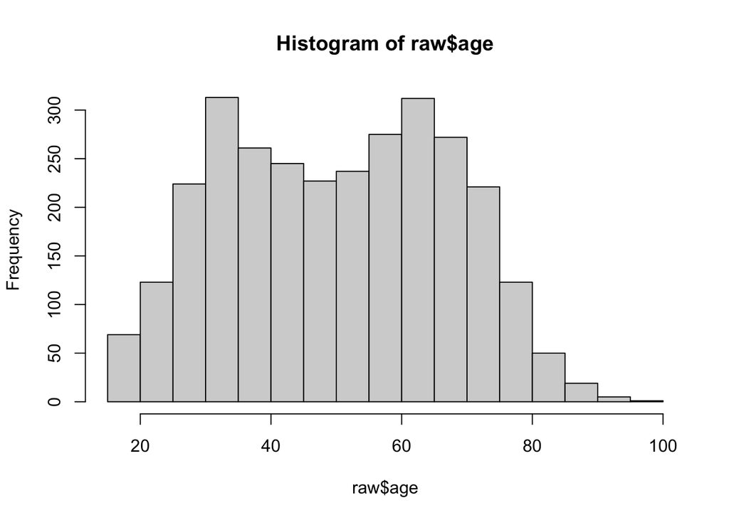

```r
hist(raw$age)
```

```r
raw %>% tabyl(age4)
```

```
##  age4    n   percent
##     1  364 0.1222707
##     2  828 0.2781323
##     3  729 0.2448774
##     4 1056 0.3547195
```

```r
raw %>% tabyl(age7)
```

```
##  age7   n    percent
##     1 166 0.05576083
##     2 512 0.17198522
##     3 514 0.17265704
##     4 453 0.15216661
##     5 583 0.19583473
##     6 523 0.17568021
##     7 226 0.07591535
```

```r
raw <-
  raw %>%
  mutate(
    age4 =
      factor(
        age4,
        levels = 1:4,
        labels =
          c("18-29",
            "30-44",
            "45-59",
            "60+")
      ),
    age7 =
      factor(
        age7,
        levels = 1:7,
        labels =
          c("18-24",
            "25-34",
            "35-44",
            "45-54",
            "55-64",
            "65-74",
            "75+")
      )
  ) %>%
  set_variable_labels(
    age = "Age",
    age4 = "Age - 4 Categories",
    age7 = "Age - 7 Categories"
  )
```

```r
raw %>% tabyl(age4)
```

```
##   age4    n   percent
##  18-29  364 0.1222707
##  30-44  828 0.2781323
##  45-59  729 0.2448774
##    60+ 1056 0.3547195
```

```r
raw %>% tabyl(age7)
```

```
##   age7   n    percent
##  18-24 166 0.05576083
##  25-34 512 0.17198522
##  35-44 514 0.17265704
##  45-54 453 0.15216661
##  55-64 583 0.19583473
##  65-74 523 0.17568021
##    75+ 226 0.07591535
```

## 8.6 Race and ethnicity

```r
raw %>% tabyl(racethnicity)
```

```
##  racethnicity    n     percent
##             1 1293 0.434329862
##             2  671 0.225394693
##             3   23 0.007725899
##             4  662 0.222371515
##             5   43 0.014444071
##             6  285 0.095733960
```

```r
raw <-
  raw %>%
  mutate(
    racethnicity =
      factor(
        racethnicity,
        levels = 1:6,
        labels =
          c("White, non-Hispanic",
            "Black, non-Hispanic",
            "Other, non-Hispanic",
            "Hispanic",
            "2+ Races, non-Hispanic",
            "Asian, non-Hispanic")
      )
  ) %>%
  set_variable_labels(
    racethnicity = "Combined race/ethnicity"
  )
```

```r
raw %>% tabyl(racethnicity)
```

```
##            racethnicity    n     percent
##     White, non-Hispanic 1293 0.434329862
##     Black, non-Hispanic  671 0.225394693
##     Other, non-Hispanic   23 0.007725899
##                Hispanic  662 0.222371515
##  2+ Races, non-Hispanic   43 0.014444071
##     Asian, non-Hispanic  285 0.095733960
```

## 8.7 Education

```r
raw %>% tabyl(educ5)
```

```
##  educ5    n    percent
##      1  144 0.04837084
##      2  565 0.18978838
##      3 1288 0.43265032
##      4  569 0.19113201
##      5  411 0.13805845
```

```r
raw <-
  raw %>%
  mutate(
    educ5 =
      factor(
        educ5,
        levels = 1:5,
        labels =
          c("Less than HS",
            "HS graduate",
            "Some college/associates degree",
            "Bachelors degree",
            "Post grad study/professional degree"
            )
      )
  ) %>%
  set_variable_labels(
    educ5 = "Highest level of education"
  )
```

```r
raw %>% tabyl(educ5)
```

```
##                                educ5    n    percent
##                         Less than HS  144 0.04837084
##                          HS graduate  565 0.18978838
##       Some college/associates degree 1288 0.43265032
##                     Bachelors degree  569 0.19113201
##  Post grad study/professional degree  411 0.13805845
```

## 8.8 Martial status

```r
raw %>% tabyl(marital)
```

```
##  marital    n    percent
##        1 1557 0.52300974
##        2  108 0.03627813
##        3  336 0.11286530
##        4  121 0.04064494
##        5  855 0.28720188
```

```r
raw <-
  raw %>%
  mutate(
    marital = droplevels(as_factor(marital))
    ) %>%
  set_variable_labels(
    marital = "Marital status"
  )
```

```r
raw %>% tabyl(marital)
```

```
##        marital    n    percent
##        Married 1557 0.52300974
##        Widowed  108 0.03627813
##       Divorced  336 0.11286530
##      Separated  121 0.04064494
##  Never married  855 0.28720188
```

## 8.9 Employment

```r
raw %>% tabyl(employ)
```

```
##  employ    n     percent
##       1 1639 0.550554249
##       2  232 0.077930803
##       3   18 0.006046355
##       4  114 0.038293584
##       5  629 0.211286530
##       6  212 0.071212630
##       7  133 0.044675848
```

```r
raw <-
  raw %>%
  mutate(
    employ = droplevels(as_factor(employ))
  )   %>%
  set_variable_labels(
    employ = "Current employment status"
  )
```

```r
raw %>% tabyl(employ)
```

```
##                                        employ    n     percent
##                  Working - as a paid employee 1639 0.550554249
##                       Working - self-employed  232 0.077930803
##  Not working - on temporary layoff from a job   18 0.006046355
##                Not working - looking for work  114 0.038293584
##                         Not working - retired  629 0.211286530
##                        Not working - disabled  212 0.071212630
##                           Not working - other  133 0.044675848
```

## 8.10 Income

```r
walk(
  select(raw, starts_with("income")) %>% names,
  ~ print(raw %>% tabyl(.x))
)
```

```
##  income   n    percent
##       1  81 0.02720860
##       2  71 0.02384951
##       3 100 0.03359086
##       4  97 0.03258314
##       5 139 0.04669130
##       6 151 0.05072220
##       7 137 0.04601948
##       8 123 0.04131676
##       9 253 0.08498488
##      10 273 0.09170306
##      11 311 0.10446758
##      12 156 0.05240175
##      13 267 0.08968760
##      14 265 0.08901579
```

[output cut: 19 more lines]

```r
raw <-
  raw %>%
  mutate(
    income =
      factor(
        income,
        levels = 1:18,
        labels =
          c("Less than $5,000",
            "$5,000-9,999",
            "$10,000-14,999",
            "$15,000-19,999",
            "$20,000-24,999",
            "$25,000-29,999",
            "$30,000-34,999",
            "$35,000-39,999",
            "$40,000-49,999",
            "$50,000-59,999",
            "$60,000-74,999",
            "$75,000-84,999",
            "$85,000-99,999",
            "$100,000-124,999",
            "$125,000-149,999",
            "$150,000-174,999",
            "$175,000-199,999",
            "$200,000 or more")
      ),
    income4 =
      factor(
        income4,
        levels = 1:4,
        labels =
          c("Less than $30,000",
            "$30,000-60,000",
            "$60,000-100,000",
            "$100,000 or more")
      ),
    income9 =
      factor(
        income9,
        levels = 1:9,
        labels =
          c("Under $10,000",
            "$10,000-20,000",
            "$20,000-30,000",
            "$30,000-40,000",
            "$40,000-50,000",
            "$50,000-75,000",
            "$75,000-100,000",
            "$100,000-150,000",
            "$150,000 or more")
      )
  )  %>%
  set_variable_labels(
    income = "Household income",
    income4 = "Household income: 4 categories",
    income9 = "Household income: 9 categories"
  )
```

```r
walk(
  select(raw, starts_with("income")) %>% names,
  ~ print(raw %>% tabyl(.x))
)
```

```
##            income   n    percent
##  Less than $5,000  81 0.02720860
##      $5,000-9,999  71 0.02384951
##    $10,000-14,999 100 0.03359086
##    $15,000-19,999  97 0.03258314
##    $20,000-24,999 139 0.04669130
##    $25,000-29,999 151 0.05072220
##    $30,000-34,999 137 0.04601948
##    $35,000-39,999 123 0.04131676
##    $40,000-49,999 253 0.08498488
##    $50,000-59,999 273 0.09170306
##    $60,000-74,999 311 0.10446758
##    $75,000-84,999 156 0.05240175
##    $85,000-99,999 267 0.08968760
##  $100,000-124,999 265 0.08901579
##  $125,000-149,999 183 0.06147128
##  $150,000-174,999 132 0.04433994
##  $175,000-199,999  81 0.02720860
##  $200,000 or more 157 0.05273766
##            income4   n   percent
##  Less than $30,000 639 0.2146456
##     $30,000-60,000 786 0.2640242
##    $60,000-100,000 734 0.2465569
##   $100,000 or more 818 0.2747733
##           income9   n    percent
##     Under $10,000 152 0.05105811
##    $10,000-20,000 197 0.06617400
##    $20,000-30,000 290 0.09741350
##    $30,000-40,000 260 0.08733624
##    $40,000-50,000 253 0.08498488
##    $50,000-75,000 584 0.19617064
##   $75,000-100,000 423 0.14208935
##  $100,000-150,000 448 0.15048707
##  $150,000 or more 370 0.12428619
```

## 8.11 State

```r
raw %>% tabyl(state)
```

```
##  state   n      percent
##     AK   1 0.0003359086
##     AL  43 0.0144440712
##     AR  21 0.0070540813
##     AZ  65 0.0218340611
##     CA 496 0.1666106819
##     CO  61 0.0204904266
##     CT  21 0.0070540813
##     DC   7 0.0023513604
##     DE  14 0.0047027209
##     FL 240 0.0806180719
##     GA  82 0.0275445079
##     HI  13 0.0043668122
##     IA  14 0.0047027209
##     ID  24 0.0080618072
##     IL 170 0.0571044676
##     IN  55 0.0184749748
##     KS  24 0.0080618072
##     KY  31 0.0104131676
##     LA  41 0.0137722539
##     MA  29 0.0097413504
##     MD  34 0.0114208935
##     ME  12 0.0040309036
##     MI  91 0.0305676856
##     MN  48 0.0161236144
##     MO  80 0.0268726906
##     MS  22 0.0073899899
##     MT  14 0.0047027209
##     NC 101 0.0339267719
##     ND   9 0.0030231777
##     NE  27 0.0090695331
##     NH  10 0.0033590863
##     NJ  55 0.0184749748
##     NM  22 0.0073899899
##     NV  28 0.0094054417
##     NY 103 0.0345985892
##     OH  98 0.0329190460
##     OK  38 0.0127645280
##     OR  27 0.0090695331
##     PA  89 0.0298958683
##     RI   7 0.0023513604
##     SC  49 0.0164595230
##     SD  11 0.0036949950
##     TN  72 0.0241854216
##     TX 234 0.0786026201
##     UT  17 0.0057104468
##     VA  62 0.0208263352
##     VT   4 0.0013436345
##     WA  64 0.0214981525
##     WI  74 0.0248572388
##     WV  20 0.0067181727
##     WY   3 0.0010077259
```

```r
raw <-
  raw %>%
  set_variable_labels(
    state = "State"
  )
```

## 8.12 Region

```r
walk(
  select(raw, starts_with("region")) %>% names,
  ~ print(raw %>% tabyl(.x))
)
```

```
##  region4    n   percent
##        1  330 0.1108498
##        2  701 0.2354720
##        3 1111 0.3731945
##        4  835 0.2804837
##  region9   n    percent
##        1  83 0.02788042
##        2 247 0.08296943
##        3 488 0.16392341
##        4 213 0.07154854
##        5 609 0.20456836
##        6 168 0.05643265
##        7 334 0.11219348
##        8 234 0.07860262
##        9 601 0.20188109
```

```r
raw <-
  raw %>%
  mutate(
    across(starts_with("region"), ~ droplevels(as_factor(.x)))
    )  %>%
  set_variable_labels(
    region4 = "4-level region",
    region9 = "9-level region"
  )
```

```r
walk(
  select(raw, starts_with("region")) %>% names,
  ~ print(raw %>% tabyl(.x))
)
```

```
##    region4    n   percent
##  Northeast  330 0.1108498
##    Midwest  701 0.2354720
##      South 1111 0.3731945
##       West  835 0.2804837
##             region9   n    percent
##         New England  83 0.02788042
##        Mid-Atlantic 247 0.08296943
##  East North Central 488 0.16392341
##  West North Central 213 0.07154854
##      South Atlantic 609 0.20456836
##  East South Central 168 0.05643265
##  West South Central 334 0.11219348
##            Mountain 234 0.07860262
##             Pacific 601 0.20188109
```

## 8.13 Metropolitan area flag

```r
raw %>% tabyl(metro)
```

```
##  metro    n   percent
##      0  387 0.1299966
##      1 2590 0.8700034
```

```r
raw <-
  raw %>%
  mutate(
    metro = droplevels(as_factor(metro))
  ) %>%
  set_variable_labels(
    metro = "Metropolitan area flag"
  )
```

```r
raw %>% tabyl(metro)
```

```
##           metro    n   percent
##  Non-Metro Area  387 0.1299966
##      Metro Area 2590 0.8700034
```

## 8.14 Internet

```r
raw %>% tabyl(internet)
```

```
##  internet    n    percent
##         0  262 0.08800806
##         1 2715 0.91199194
```

```r
raw <-
  raw %>%
  mutate(
    internet = droplevels(as_factor(internet))
  ) %>%
  set_variable_labels(
    internet = "HH internet access via dial-up, DSL, or cable broadband at home"
  )
```

```r
raw %>% tabyl(internet)
```

```
##                internet    n    percent
##  Non-internet household  262 0.08800806
##      Internet Household 2715 0.91199194
```

## 8.15 Housing

```r
raw %>% tabyl(housing)
```

```
##  housing    n    percent
##        1 1957 0.65737319
##        2  925 0.31071549
##        3   95 0.03191132
```

```r
raw <-
  raw %>%
  mutate(
    housing = droplevels(as_factor(housing))
  ) %>%
  set_variable_labels(
    housing = "Home ownership"
  )
```

```r
raw %>% tabyl(housing)
```

```
##                                                    housing    n    percent
##  Owned or being bought by you or someone in your household 1957 0.65737319
##                                            Rented for cash  925 0.31071549
##                      Occupied without payment of cash rent   95 0.03191132
```

## 8.16 Home type

```r
raw %>% tabyl(home_type)
```

```
##  home_type    n     percent
##          1 1981 0.665435002
##          2  230 0.077258986
##          3  638 0.214309708
##          4  113 0.037957676
##          5   15 0.005038629
```

```r
raw <-
  raw %>%
  mutate(
    home_type = as_factor(home_type)
  ) %>%
  set_variable_labels(
    home_type = "Type of building of panelists' residence"
  )
```

```r
raw %>% tabyl(home_type)
```

```
##                                          home_type    n     percent
##   A one-family house detached from any other house 1981 0.665435002
##  A one-family house attached to one or more houses  230 0.077258986
##               A building with 2 or more apartments  638 0.214309708
##                           A mobile home or trailer  113 0.037957676
##                                 Boat, RV, van, etc   15 0.005038629
```

## 8.17 Phone service

```r
raw %>% tabyl(phoneservice)
```

```
##  phoneservice    n     percent
##             1   79 0.026536782
##             2  274 0.092038965
##             3  460 0.154517971
##             4 2146 0.720859926
##             5   18 0.006046355
```

```r
raw <-
  raw %>%
  mutate(
    phoneservice = as_factor(phoneservice)
  ) %>%
  set_variable_labels(
    phoneservice = "Telephone service for the household"
  )
```

```r
raw %>% tabyl(phoneservice)
```

```
##                               phoneservice    n     percent
##                    Landline telephone only   79 0.026536782
##  Have a landline, but mostly use cellphone  274 0.092038965
##    Have cellphone, but mostly use landline  460 0.154517971
##                             Cellphone only 2146 0.720859926
##                       No telephone service   18 0.006046355
```

## 8.18 Are you a member of the National Rifle Association (Q39a and b)

Are you a member of the National Rifle Association–also known as the NRA? = `q39a` = `nranow`

Have you ever been a member of the National Rifle Association–also known as the NRA? = `q39b` = `nraever`

There are some observations with NA hardcoded for `q39b`. This corresponds to people who said in `q39a` that they are current members of the NRA or skipped/refused to answer `q39a`.

I group together “Skipped on web”, “Refused” as “Unknown”

```r
raw %>% tabyl(q39a, q39b)
```

```
##  q39a   1    2 98 NA_
##     1   0    0  0 132
##     2 199 2589 50   0
##    98   0    0  0   7
```

```r
raw <-
  raw %>%
  rename(
    nranow = q39a,
    nraever = q39b
    ) %>%
  mutate(
    nraever =
      case_when(
        is.na(nraever) ~ as.numeric(nranow),
        TRUE ~ as.numeric(nraever)
      ),
    across(
      starts_with("nra"),
      ~ case_when(
          .x  == 98 ~ 99,
          TRUE ~ .x) %>%
        factor(
          levels = c(1:2, 99),
          labels =
            c("Yes", "No", "Unknown")
          )
    )
  ) %>%
  set_variable_labels(
    nraever = "Have you ever been a member of the NRA?",
    nranow = "Are you a member of the NRA?"
  )
```

```r
raw %>% tabyl(nranow, nraever)
```

```
##   nranow Yes   No Unknown
##      Yes 132    0       0
##       No 199 2589      50
##  Unknown   0    0       7
```

## 8.19 Gun ownership (Q40 & 41)

Do you happen to have in your home or garage any guns or revolvers? = `q40` = `gunhome`

Do any of these guns personally belong to you? = `gunhomeper`. There are some observations with NA hardcoded for `q41`. This corresponds to people who said answered no to q40.

```r
raw %>% tabyl(q40)
```

```
##  q40    n      percent
##    1 1261 0.4235807860
##    2 1636 0.5495465233
##   98   79 0.0265367820
##   99    1 0.0003359086
```

```r
raw %>% tabyl(q41)
```

```
##  q41    n    percent valid_percent
##    1 1001 0.33624454    0.79381443
##    2  253 0.08498488    0.20063442
##   98    7 0.00235136    0.00555115
##   NA 1716 0.57641921            NA
```

```r
raw <-
  raw %>%
  rename(
    gunhome = q40,
    gunhomeper = q41
    ) %>%
  mutate(
    across(
      starts_with("gunhomeper"), as.numeric
    ),
    gunhomeper =
      case_when(
        gunhomeper > 2 | is.na(gunhomeper) ~ 2,
        TRUE ~ gunhomeper
      )  %>%
      factor(
          levels = c(1:2),
          labels =
            c("Yes", "No")
        ),
    gunhome =
      ifelse(gunhome > 2, 99, gunhome) %>%
      factor(
        levels = c(1:2, 99),
        labels =
          c("Yes", "No", "Unknown")
        )
  ) %>%
  set_variable_labels(
    gunhome = "Do you happen to have in your home or garage any guns or revolvers?",
    gunhomeper = "Do any of guns or revolvers in your home or garage personally belong to you?"
  )
```

```r
raw %>% tabyl(gunhome, gunhomeper)
```

```
##  gunhome  Yes   No
##      Yes 1001  260
##       No    0 1636
##  Unknown    0   80
```

## 8.20 Type of gun ownership

Do you personally own any of the following types of guns?

- `qguntypea` = handguns
- `qguntypeb` = rifles
- `qguntypec` = shotguns
- `qguntyped` = other

```r
walk(
  c("qguntypea", "qguntypeb", "qguntypec", "qguntyped"),
  ~ print(raw %>% tabyl(.x))
)
```

```
##  qguntypea    n     percent valid_percent
##          1  879 0.295263688    0.87812188
##          2  112 0.037621767    0.11188811
##         98   10 0.003359086    0.00999001
##         NA 1976 0.663755459            NA
##  qguntypeb    n     percent valid_percent
##          1  546 0.183406114    0.54545455
##          2  439 0.147463890    0.43856144
##         98   16 0.005374538    0.01598402
##         NA 1976 0.663755459            NA
##  qguntypec    n     percent valid_percent
##          1  513 0.172321129    0.51248751
##          2  471 0.158212966    0.47052947
##         98   17 0.005710447    0.01698302
##         NA 1976 0.663755459            NA
##  qguntyped    n      percent valid_percent
##          1  120 0.0403090359   0.119880120
##          2  813 0.2730937185   0.812187812
##         77    1 0.0003359086   0.000999001
##         98   67 0.0225058784   0.066933067
##         NA 1976 0.6637554585            NA
```

```r
raw <-
  raw %>%
  rename(
    ownhandgun = qguntypea,
    ownrifle = qguntypeb,
    ownshot = qguntypec,
    ownother = qguntyped
  ) %>%
  mutate(
    across(
      starts_with("own"),
      ~ case_when(
        is.na(.x) & gunhomeper == "No" ~ 100,
        is.na(.x) | .x == 77 | .x %in% 98:99 ~ 99,
        TRUE ~ .x
      ) %>%
        factor(
          levels = c(1:2, 99:100),
          labels =
            c("Yes",
              "No",
              "Unknown",
              "Non-gun owner")
        )
    )
  ) %>%
    set_variable_labels(
      ownhandgun = "Do you personally own any hanguns?",
      ownrifle = "Do you personally own any rifles?",
      ownshot = "Do you personally own any shotguns?",
      ownother = "Do you personally own any other types of guns?"
    )
```

```r
walk(
    raw %>% select(starts_with("own")) %>% names(),
  ~ print(raw %>% tabyl(.x))
)
```

```
##     ownhandgun    n     percent
##            Yes  879 0.295263688
##             No  112 0.037621767
##        Unknown   10 0.003359086
##  Non-gun owner 1976 0.663755459
##       ownrifle    n     percent
##            Yes  546 0.183406114
##             No  439 0.147463890
##        Unknown   16 0.005374538
##  Non-gun owner 1976 0.663755459
##        ownshot    n     percent
##            Yes  513 0.172321129
##             No  471 0.158212966
##        Unknown   17 0.005710447
##  Non-gun owner 1976 0.663755459
##       ownother    n    percent
##            Yes  120 0.04030904
##             No  813 0.27309372
##        Unknown   68 0.02284179
##  Non-gun owner 1976 0.66375546
```

## 8.21 Veteran

- `veteran_1` = Have you ever served on active duty in the U.S. Armed Forces, military Reserves, or National Guard? = `vet`
- `veteran2_1` = Are you currently on active duty in the U.S Armed Forces, military Reserves, or National Guard? = `activevet`

```r
raw %>% tabyl(veteran_1, veteran2_1)
```

```
##  veteran_1  1   2 98  NA_
##          1 16 282  2    0
##          2  0   0  0 2677
```

```r
raw <-
  raw %>%
  rename(vet = veteran_1, activevet = veteran2_1) %>%
  mutate(
    activevet =
      case_when(
        is.na(activevet) ~ vet,
        TRUE ~ activevet
      ),
    across(
      ends_with("vet"),
      ~ factor(
        .x,
        levels = c(1:2, 98),
        labels = c("Yes", "No", "Unknown")
      )
    )
  ) %>%
  set_variable_labels(
    activevet = "Are you currently on active duty in the U.S Armed Forces, military Reserves, or National Guard?",
    vet = "Have you ever served on active duty in the U.S. Armed Forces, military Reserves, or National Guard?"
  )
```

```r
raw %>% tabyl(vet, activevet)
```

```
##      vet Yes   No Unknown
##      Yes  16  282       2
##       No   0 2677       0
##  Unknown   0    0       0
```

## 8.22 Political party

```r
raw %>% tabyl(party_id7, party_id5)
```

```
##  party_id7 -1   1   2   3   4   5
##         -1 20   0   0   0   0   0
##          1  0 567   0   0   0   0
##          2  0 542   0   0   0   0
##          3  0   0 310   0   0   0
##          4  0   0   0 579   0   0
##          5  0   0   0   0 240   0
##          6  0   0   0   0   0 328
##          7  0   0   0   0   0 391
```

```r
raw <-
  raw %>%
  rename(party7 = party_id7, party5 = party_id5) %>%
  mutate(
    party7 =
      factor(
        as.numeric(party7),
        levels = c(1:7, -1),
        labels =
          c("Strong Democrat",
            "Not so strong Democrat",
            "Lean Democrat",
            "Don't Lean/Independent/None",
            "Lean Republican",
            "Not so strong Republican",
            "Strong Republican",
            "Unknown")
      ),
    party5 =
      factor(
        party5,
        levels = c(1:5, -1),
        labels =
          c("Democrat",
            "Lean Democrat",
            "Don't Lean/Independent/None",
            "Lean Republican",
            "Republican",
            "Unknown")
      )
  ) %>%
  set_variable_labels(
    party7 = "7-level political affiliation",
    party5 = "5-level political affiliation"
  )
```

```r
raw %>% tabyl(party7, party5)
```

```
##                       party7 Democrat Lean Democrat Don't Lean/Independent/None
##              Strong Democrat      567             0                           0
##       Not so strong Democrat      542             0                           0
##                Lean Democrat        0           310                           0
##  Don't Lean/Independent/None        0             0                         579
##              Lean Republican        0             0                           0
##     Not so strong Republican        0             0                           0
##            Strong Republican        0             0                           0
##                      Unknown        0             0                           0
##  Lean Republican Republican Unknown
##                0          0       0
##                0          0       0
##                0          0       0
##                0          0       0
##              240          0       0
##                0        328       0
##                0        391       0
##                0          0      20
```

## 8.23 At what age did you buy your first gun?

We define a categorical variable to match the age4 with an added category for < 18 and for not purchasing a gun (missing values). Some observations have firstgun == 998, which I assume to mean gun owners so I code them as unknown.

```r
raw %>% tabyl(firstgun_age)
```

```
##  firstgun_age    n      percent valid_percent
##            12   29 0.0097413504   0.028971029
##            13    4 0.0013436345   0.003996004
##            14   15 0.0050386295   0.014985015
##            15    8 0.0026872691   0.007992008
##            16   41 0.0137722539   0.040959041
##            17   10 0.0033590863   0.009990010
##            18  120 0.0403090359   0.119880120
##            19   29 0.0097413504   0.028971029
##            20   29 0.0097413504   0.028971029
##            21   98 0.0329190460   0.097902098
##            22   38 0.0127645280   0.037962038
##            23   24 0.0080618072   0.023976024
##            24   27 0.0090695331   0.026973027
##            25   80 0.0268726906   0.079920080
```

[output cut: 47 more lines]

```r
raw <-
  raw %>%
  rename(firstgun = firstgun_age) %>%
  mutate(
    firstgun7 =
      case_when(
        firstgun < 18 ~ "Under 18",
        firstgun %in% 18:29 ~ "18-29",
        firstgun %in% 30:44 ~ "30-44",
        firstgun %in% 45:59 ~ "45-59",
        firstgun %in% 60:100 ~ "60+",
        firstgun == 998 ~ "Unknown",
        TRUE ~ "Never purchased a gun"
      )
  ) %>%
  set_variable_labels(

  )
```

```r
raw %>% tabyl(firstgun7)
```

```
##              firstgun7    n    percent
##                  18-29  502 0.16862613
##                  30-44  216 0.07255626
##                  45-59   74 0.02485724
##                    60+   44 0.01477998
##  Never purchased a gun 1976 0.66375546
##               Under 18  107 0.03594222
##                Unknown   58 0.01948270
```

## 8.24 Household size

```r
raw <-
  raw %>%
  set_variable_labels(
    hhsize = "Household size (including children)",
    hh01 = "Number of HH members age 0-1",
    hh25 = "Number of HH members age 2-5",
    hh612 = "Number of HH members age 6-12",
    hh1317 = "Number of HH members age 13-17",
    hh18ov = "Number of HH members age 18+"
  )
```

## 8.25 Weights

`weight1` = general population analysis `weight3` = gun owner specific analysis

```r
clean <-
  raw %>%
  set_variable_labels(
    weight1 = "Post-stratification weights - 18+ general population",
    weight2 = "Post-stratified weights - scaled to 3 race groups (NH-Black, Hispanic, NH-All Other)",
weight3 = "Post-stratified weights - scaled to 2 groups (gun owners vs not gun owners)"
  )
```

## 8.26 Explore demographic variables

### 8.26.1 Gun owners

```r
demovars <-
  c(
    "age4",
    "hhsize",
    "gender",
    "racethnicity",
    "educ5",
    "marital",
    "employ",
    "income",
    "internet",
    "home_type"
  )

summstats <-
  c("notNA(x)", "mean(x)")
summnames <-
  c("Observations", "Mean")
```

```r
st(
  clean %>% filter(gunhomeper == "Yes"),
  vars = demovars,
  group.weights = "weight1",
  summ = summstats,
  summ.names = summnames,
  title = "Weighted demographic summary among gun owners",
  out = "kable",
  numformat = "comma",
  labels =  T
  ) %>%
  kable_classic(
    full_width = FALSE,
    html_font = "Cambria"
  ) %>%
  scroll_box(width = "800px", height = "500px")
```

Table 8.1: Weighted demographic summary among gun owners

| Variable | Observations | Mean |
| --- | --- | --- |
| Age - 4 Categories | 1,001 |  |
| … 18-29 | 70 | 7% |
| … 30-44 | 229 | 23% |
| … 45-59 | 268 | 27% |
| … 60+ | 434 | 43% |
| hhsize | 1001 |  |
| Respondent gender | 1,001 |  |
| … Male | 674 | 67% |
| … Female | 319 | 32% |
| … Transgender | 0 | 0% |
| … Do not identify as male, female, or transgender | 7 | 1% |
| … Unknown | 1 | 0% |
| Combined race/ethnicity | 1,001 |  |
| … White, non-Hispanic | 563 | 56% |
| … Black, non-Hispanic | 220 | 22% |
| … Other, non-Hispanic | 12 | 1% |
| … Hispanic | 142 | 14% |
| … 2+ Races, non-Hispanic | 14 | 1% |
| … Asian, non-Hispanic | 50 | 5% |
| Highest level of education | 1,001 |  |
| … Less than HS | 30 | 3% |
| … HS graduate | 188 | 19% |
| … Some college/associates degree | 492 | 49% |
| … Bachelors degree | 176 | 18% |
| … Post grad study/professional degree | 115 | 11% |
| Marital status | 1,001 |  |
| … Married | 624 | 62% |
| … Widowed | 41 | 4% |
| … Divorced | 125 | 12% |
| … Separated | 36 | 4% |
| … Never married | 175 | 17% |
| Current employment status | 1,001 |  |
| … Working - as a paid employee | 528 | 53% |
| … Working - self-employed | 78 | 8% |
| … Not working - on temporary layoff from a job | 3 | 0% |
| … Not working - looking for work | 17 | 2% |
| … Not working - retired | 285 | 28% |
| … Not working - disabled | 64 | 6% |
| … Not working - other | 26 | 3% |
| Household income | 1,001 |  |
| … Less than $5,000 | 16 | 2% |
| … $5,000-9,999 | 17 | 2% |
| … $10,000-14,999 | 19 | 2% |
| … $15,000-19,999 | 27 | 3% |
| … $20,000-24,999 | 35 | 3% |
| … $25,000-29,999 | 49 | 5% |
| … $30,000-34,999 | 41 | 4% |
| … $35,000-39,999 | 39 | 4% |
| … $40,000-49,999 | 80 | 8% |
| … $50,000-59,999 | 91 | 9% |
| … $60,000-74,999 | 119 | 12% |
| … $75,000-84,999 | 59 | 6% |
| … $85,000-99,999 | 111 | 11% |
| … $100,000-124,999 | 97 | 10% |
| … $125,000-149,999 | 72 | 7% |
| … $150,000-174,999 | 59 | 6% |
| … $175,000-199,999 | 28 | 3% |
| … $200,000 or more | 42 | 4% |
| HH internet access via dial-up, DSL, or cable broadband at home | 1,001 |  |
| … Non-internet household | 77 | 8% |
| … Internet Household | 924 | 92% |
| Type of building of panelists’ residence | 1,001 |  |
| … A one-family house detached from any other house | 772 | 77% |
| … A one-family house attached to one or more houses | 57 | 6% |
| … A building with 2 or more apartments | 128 | 13% |
| … A mobile home or trailer | 39 | 4% |
| … Boat, RV, van, etc | 5 | 0% |

### 8.26.2 Full sample

```r
demovars <- c("gunhomeper", demovars)
```

```r
st(
  clean,
  vars = demovars,
  group.weights = "weight1",
  summ = summstats,
  summ.names = summnames,
  title = "Weighted demographic summary among full sample",
  out = "kable",
  numformat = "comma",
  labels =  T
  ) %>%
  kable_classic(
    full_width = FALSE,
    html_font = "Cambria"
  ) %>%
  scroll_box(width = "800px", height = "500px")
```

Table 8.2: Weighted demographic summary among full sample

| Variable | Observations | Mean |
| --- | --- | --- |
| Do any of guns or revolvers in your home or garage personally belong to you? | 2,977 |  |
| … Yes | 1,001 | 34% |
| … No | 1,976 | 66% |
| Age - 4 Categories | 2,977 |  |
| … 18-29 | 364 | 12% |
| … 30-44 | 828 | 28% |
| … 45-59 | 729 | 24% |
| … 60+ | 1,056 | 35% |
| hhsize | 2977 |  |
| Respondent gender | 2,977 |  |
| … Male | 1,546 | 52% |
| … Female | 1,400 | 47% |
| … Transgender | 8 | 0% |
| … Do not identify as male, female, or transgender | 20 | 1% |
| … Unknown | 3 | 0% |
| Combined race/ethnicity | 2,977 |  |
| … White, non-Hispanic | 1,293 | 43% |
| … Black, non-Hispanic | 671 | 23% |
| … Other, non-Hispanic | 23 | 1% |
| … Hispanic | 662 | 22% |
| … 2+ Races, non-Hispanic | 43 | 1% |
| … Asian, non-Hispanic | 285 | 10% |
| Highest level of education | 2,977 |  |
| … Less than HS | 144 | 5% |
| … HS graduate | 565 | 19% |
| … Some college/associates degree | 1,288 | 43% |
| … Bachelors degree | 569 | 19% |
| … Post grad study/professional degree | 411 | 14% |
| Marital status | 2,977 |  |
| … Married | 1,557 | 52% |
| … Widowed | 108 | 4% |
| … Divorced | 336 | 11% |
| … Separated | 121 | 4% |
| … Never married | 855 | 29% |
| Current employment status | 2,977 |  |
| … Working - as a paid employee | 1,639 | 55% |
| … Working - self-employed | 232 | 8% |
| … Not working - on temporary layoff from a job | 18 | 1% |
| … Not working - looking for work | 114 | 4% |
| … Not working - retired | 629 | 21% |
| … Not working - disabled | 212 | 7% |
| … Not working - other | 133 | 4% |
| Household income | 2,977 |  |
| … Less than $5,000 | 81 | 3% |
| … $5,000-9,999 | 71 | 2% |
| … $10,000-14,999 | 100 | 3% |
| … $15,000-19,999 | 97 | 3% |
| … $20,000-24,999 | 139 | 5% |
| … $25,000-29,999 | 151 | 5% |
| … $30,000-34,999 | 137 | 5% |
| … $35,000-39,999 | 123 | 4% |
| … $40,000-49,999 | 253 | 8% |
| … $50,000-59,999 | 273 | 9% |
| … $60,000-74,999 | 311 | 10% |
| … $75,000-84,999 | 156 | 5% |
| … $85,000-99,999 | 267 | 9% |
| … $100,000-124,999 | 265 | 9% |
| … $125,000-149,999 | 183 | 6% |
| … $150,000-174,999 | 132 | 4% |
| … $175,000-199,999 | 81 | 3% |
| … $200,000 or more | 157 | 5% |
| HH internet access via dial-up, DSL, or cable broadband at home | 2,977 |  |
| … Non-internet household | 262 | 9% |
| … Internet Household | 2,715 | 91% |
| Type of building of panelists’ residence | 2,977 |  |
| … A one-family house detached from any other house | 1,981 | 67% |
| … A one-family house attached to one or more houses | 230 | 8% |
| … A building with 2 or more apartments | 638 | 21% |
| … A mobile home or trailer | 113 | 4% |
| … Boat, RV, van, etc | 15 | 1% |

## 8.27 Export data

```r
write_rds(
  clean,
  here(
    path_od,
    "data",
    "clean",
    "gs-2025.rds"
    )
  )
```

```r
nrow(clean)
```

```
## [1] 2977
```